# Papers and Bibliographies in Quarto

Lecture 06b  
POLS 6394 · Thursday, October 1

## Today

- Turn prose, code, figures, and citations into a paper
- Keep results in the text synchronized with the data
- Format and cross-reference figures and tables
- Write equations and quotations; hypotheses are in If Time Remains
- Import citations and change citation styles
- Use the final five minutes to start your own paper

# From a workbook to a paper

## Before you render: install the table package

If you haven’t installed `modelsummary`, run this once in the **R Console**, not in a document chunk:

```r
install.packages("modelsummary")
```

This installs the package and its required dependencies, including `tinytable`. Wait for installation to finish before rendering the demo. If it fails, we can help while you work through the earlier sections.

## The paper we saw in 01b

Open `Demos/paper/paper-example.qmd`, choose Typst from the Render menu, and open its PDF beside the source. Keep any practice copy in `Demos/paper/` so its relative paths still work.

Find the abstract, sections, figure, footnote, citations, and references. Today we’ll learn how those parts work, rather than repeat the Markdown tour.

The demo keeps its source, data, and bibliography together in `Demos/paper/`. Your semester paper belongs in `Paper/`; keep its dependencies with the project.

## Setup: run this chunk as written

We’ll use Tuesday’s state-year cigarette data: annual packs per capita (`packpc`) and tax adjusted for inflation (`real_tax`).

The full paper demo uses the same annual data and column names. Its own data copy lives in `Demos/paper/Data/` so the demo renders from that folder.

```r
library(tidyverse)
library(knitr)

cigarettes <- read_csv(
  "Data/cigarettes/cigarette.csv", show_col_types = FALSE
) |>
  select(-rownames) |>
  mutate(real_tax = tax / cpi)
```

## Look at a few rows first

Each row is one state in one year. Sample the data before using it in a paper.

```r
set.seed(6394)
cigarettes |>
  select(state, year, packpc, real_tax) |>
  slice_sample(n = 5)
```

```
# A tibble: 5 × 4
  state  year packpc real_tax
  <chr> <dbl>  <dbl>    <dbl>
1 NY     1995   70.8     52.5
2 CT     1987  107.      37.0
3 WI     1992   94.5     36.6
4 IL     1990   96.0     35.2
5 AL     1990  112.      24.9
```

## What belongs in the title block?

The YAML names the paper, author, abstract, bibliography, and outputs.

```yaml
title: "Cigarette Taxes and Consumption"
author: "Your name or initials"
abstract: |
  This paper describes changes in cigarette
  consumption across U.S. states.
bibliography: references.bib
number-sections: true
```

`|` continues the abstract across indented lines. `number-sections` numbers headings; `bibliography` names a file, not a citation key.

## Authors and affiliations

To add an affiliation or a second author, write `author` as a list:

```yaml
author:
  - name: Ana Ruiz
    affiliation: University of Houston
  - name: Sam Lee
    affiliation: Rice University
```

Each hyphen (`-`) starts one entry. The indented lines below it belong to that entry. Next class, your CV’s data files use the same list format.

## Find your place in a long paper

Open the document outline in RStudio’s Source pane. Click a heading to jump to that section instead of scrolling.

Give each chunk a descriptive, unique label, such as `setup` or `fig-taxes`. Labels help you find the calculation named in a render error.

Keep the paper and workbook open in separate tabs. Use the workbook as a reference while editing your paper.

## One source, three outputs

Choose an output from the Render button’s menu.

```yaml
format:
  html:
    embed-resources: true
  docx: default
  typst: default
```

HTML is convenient for checking your work; Word supports editable drafts; Typst creates the PDF. Each render reruns the analysis.

## PDF: keep using Typst

We used Typst in 01b, and we’ll use it here. It comes with Quarto; there’s no separate TeX installation for today’s student work.

LaTeX is another PDF route, often used by journal templates. `pdf:` selects that route; `typst:` selects Typst. Both produce a `.pdf` file.

## Word edits don’t change the source

A coauthor can comment on or edit the Word export. Those changes don’t automatically return to the QMD.

Keep the QMD as the source. Incorporate accepted edits there, then render a new draft. Otherwise the Word and PDF versions can disagree.

# Code and results in a manuscript

## Hide code, keep the results

A manuscript usually shows results rather than the code that produced them.

```yaml
execute:
  echo: false
```

This document-wide setting hides code unless a chunk overrides it with `#| echo: true`. It doesn’t stop the code from running.

## Three chunk options

| Option | Runs code? | Shows code? | Shows results? |
| --- | --- | --- | --- |
| `echo: false` | Yes | No | Yes |
| `include: false` | Yes | No | No |
| `eval: false` | No | Yes, unless hidden | No |

Use `include: false` for setup, `echo: false` for manuscript results, and `eval: false` for unfinished or deliberately broken examples.

## Rendering starts a fresh R session

Running a chunk interactively can use objects already in your Environment pane. Rendering runs the document from the beginning in a fresh R session.

Put package loads, data reads, and necessary calculations in the source. An object created only in the Console won’t be available.

Suppose you created `my_result` only in the Console. This chunk would fail during rendering:

```r
my_result
```

Include the calculation in the document **before** the chunk that uses it. Read the first error rather than repeatedly clicking Render.

## Compute numbers for the prose

Count the number of distinct states and years. Save the results as objects:

```r
n_states <- n_distinct(cigarettes$state)
n_years <- n_distinct(cigarettes$year)
n_states
```

```
[1] 48
```

```r
n_years
```

```
[1] 11
```

`n_distinct()` counts distinct values. We can insert these numbers directly into a sentence.

## Inline R keeps the text updated

Write a backtick, `r`, a space, an R expression, and a closing backtick:

```markdown
The data cover `r n_states` states across `r n_years` years.
```

Rendered result:

The data cover 48 states across 11 years.

Unlike a chunk, inline R puts its result inside a sentence. Keep the expression short.

## Your Turn: report a change in one sentence

*~4 minutes. Answer on the next slide.*

This chunk computes the 1985 and 1995 means and the percentage change. Add an option line at the top of the chunk, `#| ___: false`, choosing the option that runs the code but keeps the code and its output out of the paper.

```r
# Add the chunk option above this line.
mean_1985 <- cigarettes |>
  filter(year == 1985) |>
  summarize(packs = mean(packpc)) |>
  pull(packs)
mean_1995 <- cigarettes |>
  filter(year == 1995) |>
  summarize(packs = mean(packpc)) |>
  pull(packs)
pct_change <- 100 * (mean_1995 - mean_1985) / mean_1985
```

Then write one sentence giving both means (whole packs) and the percentage change (one decimal). Every number must come from inline R.

**Your sentence:** ___

**If you finish early:** make the word “fell” come from inline R too, so the sentence would say “rose” if consumption had increased. `if_else()` from 06a can choose between two words.

## Change in consumption: the answer

`include: false` runs the chunk but shows neither the code nor its output.

```markdown
Mean consumption fell from `r round(mean_1985)`
to `r round(mean_1995)` packs per capita,
a change of `r round(pct_change, 1)`%.
```

Mean consumption fell from 122 to 96 packs per capita, a change of -21.1%.

Early finishers replace “fell” with `` `r if_else(pct_change < 0, "fell", "rose")` ``. These are unweighted means across states, not population-weighted national averages.

# Figures and tables

## Give a figure a label and caption

Use a `fig-` label to identify the figure and `fig-cap` to supply its numbered caption.

```r
#| label: fig-taxes
#| fig-cap: "Each point is a U.S. state in 1995; the line is a linear fit."
```

The label stays in the source; the caption appears in the paper. The plot’s `labs(title = ...)` supplies text inside the plot, not the Quarto caption.

## Generate the figure from code

This is familiar plotting code. In a manuscript we hide it and retain the figure.

```r
cigarettes |>
  filter(year == 1995) |>
  ggplot(aes(x = real_tax, y = packpc)) +
  geom_point(alpha = 0.7) +
  geom_smooth(method = "lm", se = FALSE, color = "firebrick") +
  labs(title = "Taxes and consumption across states, 1995",
       x = "Real tax (cents)", y = "Packs per capita",
       caption = "Source: Stock and Watson state cigarette data.") +
  theme_bw()
```

## The figure in the paper

The caption and plot title serve different purposes. Keep limitations in the surrounding text or a footnote.

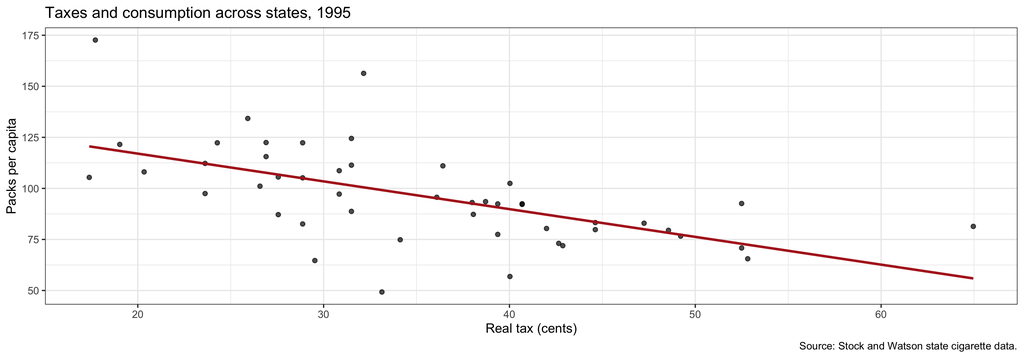

Figure 1: Each point is a U.S. state in 1995; the line is a linear fit.

## Refer to the figure by its label

Write this in the source:

```markdown
@fig-taxes compares taxes and consumption across states.
```

Figure 1 compares taxes and consumption across states.

Adding a figure earlier changes its number automatically. Keep the label stable when you move the chunk.

## A tibble becomes a manuscript table

Our summary is a tibble. `kable()`, from **knitr**, formats it for the document.

```r
endpoint_means <- cigarettes |>
  filter(year %in% c(1985, 1995)) |>
  group_by(year) |>
  summarize(mean_packs = mean(packpc))
endpoint_means
```

```
# A tibble: 2 × 2
   year mean_packs
  <dbl>      <dbl>
1  1985      122.
2  1995       96.3
```

The analysis produces the values; the table formatter controls how readers see them.

## Format the table and give it a caption

`digits = 1` prints one decimal place; `col.names` supplies readable headings without renaming the tibble’s variables.

```r
endpoint_means |>
  kable(digits = 1, col.names = c("Year", "Mean packs per capita"))
```

Table 1: Mean packs per capita across states.

| Year | Mean packs per capita |
| --- | --- |
| 1985 | 122.0 |
| 1995 | 96.3 |

Table 1 presents the endpoint means. The label starts with `tbl-` rather than `fig-`.

## Long for analysis, wide for readers

A reader may want to compare two years side by side. Compute the group summaries in long format, then widen them for the paper.

First, identify states whose real cigarette tax rose between the two years:

```r
tax_groups <- cigarettes |>
  filter(year %in% c(1985, 1995)) |>
  select(state, year, real_tax) |>
  pivot_wider(names_from = year, values_from = real_tax) |>
  mutate(group = if_else(
    `1995` > `1985`, "Tax rose", "Tax did not rise"
  )) |>
  select(state, group)
```

The year-column names need backticks because they begin with digits. `if_else()` assigns a group from the comparison; these are observational groups, not randomized treatments.

Here “Tax rose” means any increase. In 06a we used a rise of more than 10 real cents, so these groups are different. Keep the definition with the figure you copy into your paper.

## Put the years in separate columns

Join the group labels to the state-year data, calculate the means, then put each year in its own column.

```r
group_means <- cigarettes |>
  left_join(tax_groups, by = "state") |>
  filter(year %in% c(1985, 1995)) |>
  group_by(group, year) |>
  summarize(mean_packs = mean(packpc)) |>
  ungroup() |>
  pivot_wider(names_from = year, values_from = mean_packs)
group_means
```

```
# A tibble: 2 × 3
  group            `1985` `1995`
  <chr>             <dbl>  <dbl>
1 Tax did not rise   125.  109.
2 Tax rose           121.   93.0
```

`ungroup()` removes the remaining group setting before we reshape. Keep this numeric tibble for further calculations.

## Make the comparison easy to read

Use headings and a caption to identify the years, units, and sample. Round the display rather than changing the stored means.

```r
group_means |>
  kable(digits = 1, col.names = c(
    "Real tax change", "1985", "1995"
  ))
```

Table 2: Mean cigarette consumption by real tax change.

| Real tax change | 1985 | 1995 |
| --- | --- | --- |
| Tax did not rise | 124.8 | 109 |
| Tax rose | 121.3 | 93 |

**Note:** Values are unweighted means across states, in packs per capita. Groups reflect the change in inflation-adjusted taxes from 1985 to 1995. Source: Stock and Watson state cigarette data.

Table 2 puts the two years beside each other; the long data still supply the analysis.

## From a fitted model to a regression table

You shouldn’t have to copy coefficients from the Console into your paper. `modelsummary()`, from the **modelsummary** package, builds a table from the fitted model.

First, attach a region to each state so we can compare models with and without region fixed effects.

```r
library(modelsummary)
state_regions <- tibble(
  state = state.abb, region = state.region
)
model_data <- cigarettes |>
  filter(year == 1995) |>
  left_join(state_regions, by = "state")
```

`state.abb` and `state.region` are matching built-in **base R** vectors of state abbreviations and Census regions. `region` is a factor. The join adds it to the 1995 data without changing the sample.

## Fit and label two models

The second model adds region indicators, allowing the intercept to differ across regions.

```r
tax_model <- lm(packpc ~ real_tax, data = model_data)
region_model <- lm(
  packpc ~ real_tax + region, data = model_data
)
models <- list(
  "Baseline" = tax_model,
  "Region FE" = region_model
)
```

`lm()` is from **base R**: outcome on the left of `~`, predictors on the right. Adding a factor includes its indicators automatically, omitting one reference region. `list()` collects the fitted models; its names become the table’s column headings.

## Show which model has fixed effects

Add a row so readers can see which model includes region fixed effects even though the region coefficients are hidden.

```r
fe_row <- tibble(
  term = "Region fixed effects",
  "Baseline" = "N", "Region FE" = "Y"
)
```

`term` supplies the row label. The other column names match the model labels exactly. Pass this tibble as `add_rows` in `modelsummary()`.

## Format the regression table

Use `modelsummary()` to choose readable labels and the statistics to display.

```r
modelsummary(
  models, fmt = 2,
  stars = TRUE,
  coef_map = c(
    "(Intercept)" = "Intercept",
    "real_tax" = "Real tax (cents)"
  ),
  gof_map = c("nobs", "r.squared"), add_rows = fe_row,
  notes = c("OLS; outcome: packs per capita. Standard errors in parentheses.",
            "Model 2 includes region fixed effects; their coefficients are omitted.")
)
```

`fmt` sets decimal places. `coef_map` selects and relabels coefficient rows; unlisted region terms stay in the model but aren’t printed. `gof_map` selects the observation count and R-squared.

## Stars and table notes

`stars = TRUE` uses the package defaults and prints their p-value thresholds below the table:

- `+`: p < .10
- `*`: p < .05
- `**`: p < .01
- `***`: p < .001

`notes` identifies the outcome, the standard errors in parentheses, and the region fixed effects. The stars don’t tell us the size of an effect or whether it is causal.

## A regression table in the paper

Give the chunk a `tbl-` label and caption. The default table output adapts to the document format. `results: asis` inserts formatted output directly into the document instead of printing it as ordinary text. It does not hide the code or stop R from running; those are separate options.

Table 3: Cigarette taxes and consumption across states, 1995.

|  | Baseline | Region FE |
| --- | --- | --- |
| Intercept | 144.21*** | 160.90*** |
|  | (10.11) | (13.18) |
| Real tax (cents) | -1.36*** | -1.50*** |
|  | (0.28) | (0.28) |
| Num.Obs. | 48 | 48 |
| R2 | 0.346 | 0.545 |
| Region fixed effects | N | Y |

+ p < 0.1, * p < 0.05, ** p < 0.01, *** p < 0.001  
OLS; outcome: packs per capita. Standard errors in parentheses.  
Model 2 includes region fixed effects; their coefficients are omitted.

## Write about the model by its label

Refer to the table without typing its number:

```markdown
@tbl-tax-model reports the tax–consumption association.
```

Table 3 reports the tax–consumption association. This observational comparison doesn’t establish a causal effect.

Changing the model and rendering again updates the table. Keep the statistical explanation in your paper; the formatting function doesn’t supply it.

## A footnote for a qualification

A footnote can hold a short limitation that interrupts the paragraph.

```markdown
The comparison describes a change over time.^[It doesn't
separate tax changes from other changes in the states.]
```

The comparison describes a change over time.<sup>1</sup>

[^1]: It doesn’t separate tax changes from other changes in the states.

## Cross-reference a section

Give a heading a `sec-` identifier, then refer to it in prose.

```markdown
# Data and Measures {#sec-data}

See @sec-data for the definitions.
```

Section numbers update when sections move. This is useful when a reviewer asks you to reorganize a paper.

## An appendix

An appendix can hold detailed coding decisions or checks without interrupting the main argument.

```markdown
# Appendix: Data checks {.unnumbered}

Describe missing values, exclusions, and additional checks here.
```

`{.unnumbered}` keeps a heading out of the section numbering. Keep the limitation itself in the main text; the appendix supplies the detail.

# Equations

## A simple equation

Math goes between dollar signs. One `$` on each side keeps math inside a sentence. Two `$$` on each side put it on its own line, and a label after the closing `$$` numbers it.

```markdown
$$
y = \alpha + \beta x + \varepsilon
$$ {#eq-model}

In @eq-model, $\beta$ is the coefficient on $x$.
```

`\alpha`, `\beta`, and `\varepsilon` produce the Greek letters.

## The rendered equation

$$y = \alpha + \beta x + \varepsilon
\tag{1}$$

In Equation 1, $y$ is packs per capita, $x$ is the real tax, and $\varepsilon$ is the error term, representing variation not explained by the model.

Equations render in HTML, Word, and Typst PDF.

# Citations and bibliography files

## Citation keys connect prose to sources

A `.bib` file contains one entry per source. Its first line gives the entry type and key.

```
@article{jenkins_measuring_2016,
  author = {Jenkins, Jeffery A. and Monroe, Nathan W.},
  title = {On Measuring Legislative Agenda-Setting Power},
  journal = {American Journal of Political Science},
  year = {2016}, volume = {60}, number = {1},
  pages = {158--174}
}
```

The key `jenkins_measuring_2016` must match the key used in your prose.

## Parenthetical and in-text citations

| Source syntax | Rendered result |
| --- | --- |
| `[@cox_setting_2005]` | (Cox and McCubbins 2005) |
| `@anzia_legislative_2013` | Anzia and Jackman (2013) |
| `Jenkins and Monroe [-@jenkins_measuring_2016]` | Jenkins and Monroe (2016) |

Use the in-text form when the authors are the subject of your sentence. The leading `-` in `[-@key]` suppresses the author name, leaving the year when you’ve already named the authors.

## Multiple sources and page references

A semicolon separates sources. A page locator identifies the passage you’re citing.

| Source syntax | Rendered result |
| --- | --- |
| `[@cox_legislative_1993; @cox_setting_2005]` | (Cox and McCubbins 1993, 2005) |
| `[@cox_setting_2005, p. 12]` | (Cox and McCubbins 2005, 12) |

The page number demonstrates syntax; check the relevant passage before using a locator in your own paper.

## Quote a source

Put a short quotation in quotation marks and cite its page:

```markdown
They argue that "exact words from the source" [@cox_setting_2005, p. 12].
```

For a longer quotation, start each line with `>`. Put the citation at the end:

```markdown
> Exact words from the source, copied carefully,
> long enough to set apart. [@cox_setting_2005, p. 12]
```

> Exact words from the source, copied carefully, long enough to set apart. (Cox and McCubbins 2005, 12)

Copy the words exactly, and always give the page.

## Import a citation from Google Scholar

Find a paper on [Google Scholar](https://scholar.google.com). Click the quotation-mark **Cite** button, then **BibTeX**.

Copy the complete entry, including its closing brace. Paste it into your bibliography in JabRef or a text editor. You need the BibTeX entry, not the formatted citation from the popup.

Compare the entry with the publication itself:

- authors and their order
- title, year, publication type
- journal, volume, issue, and pages when applicable

Choose a recognizable, unique key. If you change a key after citing it, update the citations in the QMD too.

## Manage the file with JabRef

[JabRef](https://www.jabref.org) edits `.bib` files directly.

I’ll demonstrate opening a library, importing a copied BibTeX entry, checking its fields, and saving it. Then I’ll cite the new key in a copy of the demo paper and render it; watch the key in both files. If JabRef isn’t installed yet, use the text editor today and install it before October 6.

The same saved file is what Quarto reads.

## A reusable library and a paper’s bibliography

A master library can hold sources for many projects. A paper should travel with the bibliography it needs, not depend on a path to another computer’s library.

The supplied examples use `Demos/paper/paper-example.bib`. For your paper, keep its bibliography in `Paper/` beside the QMD.

## Where the reference list appears

Quarto puts the reference list where it finds this block, usually at the end:

```markdown
# References {.unnumbered}

::: {#refs}
:::
```

`{#refs}` marks the spot. `{.unnumbered}` keeps the heading out of the section numbering, as in the appendix.

Only sources you cite appear in the list; saving an entry in the library doesn’t add it. Next class, your CV is the exception: its template lists every entry in a publications `.bib`.

## Change the style, not the entries

The lesson supplies two CSL files in `Styles/`. **CSL** means Citation Style Language.

```yaml
csl: Styles/american-political-science-association.csl
```

Change that path to `Styles/apa.csl` and render again. The references and citations change format; the bibliography entries stay the same.

These paths work from the lesson root. A paper in `Paper/` needs `../Styles/...`, or a copy of the style beside it.

## Your Turn: cite a source and change its style

*~3 minutes.*

The supplied bibliography includes `anzia_legislative_2013`. Add a sentence introducing Anzia and Jackman’s paper on legislative organization, using the in-text citation form.

**Your citation sentence:** ___

Render to HTML with APSA, then change the YAML’s CSL path to `Styles/apa.csl` and render again. Compare the new citation and reference entry. Keep either supplied style; don’t edit the BibTeX entry to change formatting.

## When a citation doesn’t resolve

If a key is missing or misspelled, rendering can warn that the citation wasn’t found.

Check the spelling against the entry’s first line. Check the YAML bibliography path and save both files. A successful render can still contain unresolved citations; inspect the output.

# Check and save the document

## Inspect each output

Render this workbook to HTML, Word, and Typst PDF with the Render menu.

Check the figure, formatted table, cross-references, citations, and reference list. Open the actual files rather than assuming all formats look identical.

Commit the QMD and any bibliography/style files you changed. HTML stays local because the coursework repository ignores it.

For the paper milestone, also commit the PDF. Include a Word draft when needed. Don’t change the ignore rules just to submit today’s HTML.

## Your setup and data preview

The starter has a complete package-loading chunk. Add a read only when you have data; adjust the path to your file.

```r
#| label: setup
#| include: false
library(tidyverse)
paper_data <- read_csv("../Data/my-data.csv", show_col_types = FALSE)
```

In a **separate** chunk, use `set.seed(6394)` and `paper_data |> slice_sample(n = 5)`. `../` means one folder up from `Paper/`; check the file’s location before running it.

## Your 06a figure in your paper

Tuesday’s makeover figure can be your paper’s first figure. Copy its **code**, not the PNG, so each render rebuilds the figure from the data.

Rendering starts a fresh session, so `paper.qmd` needs every step the plot uses, in order:

1. setup: load the packages, then read and prepare the cigarette data from `../Data/cigarettes/cigarette.csv`;
2. the chunk that builds `tax_groups` and `trends`;
3. the plot code (`p_two`, then `makeover`) in one chunk with a figure label and caption:

```r
#| label: fig-makeover
#| fig-cap: "Mean packs per capita by real tax change, 1985–1995."
```

If your paper uses other data, follow the same steps with your own figure.

# Lab

*~5 minutes, including saving and pushing.*

## Task 1: start your paper

Work in `Paper/paper.qmd`. If it doesn’t exist, open `Paper/06b-paper-starter.qmd` and **Save As** `Paper/paper.qmd`. Copy prose from your one-page plan into it; keep the original plan. Don’t replace an existing paper or bibliography.

- **Minimum before leaving:** save your QMD with section headings and a runnable setup chunk.
- **Next:** import a relevant Scholar entry into your bibliography and cite it. Finish this at home if needed.
- **If data are ready:** read them and preview a few rows. No data yet is fine.
- **If time remains:** copy your 06a figure code. The optional hypothesis section shows how to number hypotheses later.

## Before Next Class

Save, render if possible, inspect changes, commit, push, and confirm the commit on GitHub. If unfinished code prevents rendering, disable that chunk and still push your saved source.

- **By 7:00 PM Monday, October 5:** finish the workbook’s inline-result and citation/style exercises; save your paper QMD with headings, setup, and at least one real citation. Preview data only if you have them.
- **October 6 milestone:** your paper skeleton renders to PDF with a managed bibliography, three real citations, and a first figure or approved equivalent.
- Install JabRef before October 6 if you used the editor today.
- Next class: your CV and minimal website. Bibliography entries can also supply your CV’s publications.

# If Time Remains

## Extension 1a: repair a missing citation

*~8–10 minutes for the citation repairs.*

In a copy kept in `Demos/paper/`, change one citation key by a single letter and render to HTML or Typst PDF.

Find the warning and affected citation. Correct the key, save, and render again. This deliberately broken version is for diagnosis, not submission.

## Extension 1b: repair a duplicate key

A library should have one entry per key. Two entries with the same key can leave the intended source ambiguous.

Open `Demos/bibliography-repair.bib` in JabRef or the text editor. Its two different publications share `legislatures`. Give them different keys, such as `cox_setting_2005` and `shor_ideological_2011`; citations must then use the matching key for each source.

## Extension 2: try a journal-style template

*~5 minutes.*

A Quarto template packages a layout with a starter document. In the Terminal, run these lines one at a time:

```bash
mkdir ~/template-test
cd ~/template-test
quarto use template quarto-ext/typst-templates/ams
```

`mkdir` makes a new folder in your home directory, outside your coursework repository. `cd` moves into it. The last line downloads the template; answer yes when asked whether you trust its authors.

Open the new `template-test.qmd`, render it, and compare its YAML with your paper’s. Next class uses the same command to install the CV template.

## Extension 3a: state a hypothesis

Write each hypothesis in a block. `:::` opens and closes the block; `{#thm-tax}` gives it a label.

```markdown
::: {#thm-tax}
States with higher cigarette taxes have lower consumption.
:::

@thm-tax predicts a negative relationship.
```

`thm-` blocks are Quarto’s numbered statements (`thm` is short for theorem). These YAML lines rename them:

```yaml
language:
  crossref-thm-title: "Hypothesis"
  crossref-thm-prefix: "Hypothesis"
```

## Extension 3b: the rendered hypothesis

**Hypothesis 1** States with higher cigarette taxes have lower consumption.

Hypothesis 1 predicts a negative relationship between taxes and consumption.

A second block with its own label becomes Hypothesis 2. Refer to each by its label, so the numbers stay right when you reorder them.

## Extension 3c — Your Turn: a second hypothesis

*~3 minutes.*

Add a second hypothesis in its own block with a new `thm-` label: for example, that states with larger tax increases saw larger declines in consumption. Then write one sentence that refers to both hypotheses and to the equation by their labels.

Render and check that the new block reads Hypothesis 2 and that each reference shows a number.

**Your hypothesis and sentence:** ___

## Extension 4a: change the order of a paper

*~5 minutes for the demonstration and check.*

Use a copy of the demo paper in `Demos/paper/`.

Copy the chunk labeled `fig-makeover` and insert the copy before the original, using `fig-tax-copy` as the new label. Add a sentence referring to both figures, then render.

The original figure now has a different number. The reference to its existing label still points to the right figure.

## Extension 4b: move a hypothesis and add a source

After Extension 3c, work in a copy of this workbook. Move the second hypothesis before the first, keeping both labels unchanged. Add a citation to an unused entry in the supplied bibliography and render.

Check that the hypothesis references follow the new numbering and the cited source appears in the reference list. Don’t type the replacement numbers into the prose.

These edits are practice copies, not additional submissions.

# References

Anzia, Sarah F., and Molly C. Jackman. 2013. “Legislative Organization and the Second Face of Power: Evidence from U.S. State Legislatures.” *The Journal of Politics* 75(1): 210–24.

Cox, Gary W., and Mathew D. McCubbins. 1993. *Legislative Leviathan: Party Government in the House*. Berkeley: University of California Press.

Cox, Gary W., and Mathew D. McCubbins. 2005. *Setting the Agenda: Responsible Party Government in the U.S. House of Representatives*. Cambridge: Cambridge University Press.

Jenkins, Jeffery A., and Nathan W. Monroe. 2016. “On Measuring Legislative Agenda-Setting Power.” *American Journal of Political Science* 60(1): 158–74.